# Part I - Prosper Loan Data Exploration

## Introduction

This data set contains 113,937 loans with 81 variables on each loan, including loan amount, borrower rate (or interest rate), current loan status, borrower income, and many others.

## Preliminary Wrangling

```python
# import all packages and set plots to be embedded inline
import numpy as np
import pandas as pd
import matplotlib.pyplot as plt
import seaborn as sb

%matplotlib inline
```

```python
loan_df = pd.read_csv('prosperLoanData.csv')
loan_df.head()
```

|  | ListingKey | ListingNumber | ListingCreationDate | CreditGrade | Term | LoanStatus | ClosedDate | BorrowerAPR | BorrowerRate | LenderYield | ... | LP_ServiceFees | LP_CollectionFees | LP_GrossPrincipalLoss | LP_NetPrincipalLoss | LP_NonPrincipalRecoverypayments | PercentFunded | Recommendations | InvestmentFromFriendsCount | InvestmentFromFriendsAmount | Investors |
| --- | --- | --- | --- | --- | --- | --- | --- | --- | --- | --- | --- | --- | --- | --- | --- | --- | --- | --- | --- | --- | --- |
| 0 | 1021339766868145413AB3B | 193129 | 2007-08-26 19:09:29.263000000 | C | 36 | Completed | 2009-08-14 00:00:00 | 0.16516 | 0.1580 | 0.1380 | ... | -133.18 | 0.0 | 0.0 | 0.0 | 0.0 | 1.0 | 0 | 0 | 0.0 | 258 |
| 1 | 10273602499503308B223C1 | 1209647 | 2014-02-27 08:28:07.900000000 | NaN | 36 | Current | NaN | 0.12016 | 0.0920 | 0.0820 | ... | 0.00 | 0.0 | 0.0 | 0.0 | 0.0 | 1.0 | 0 | 0 | 0.0 | 1 |
| 2 | 0EE9337825851032864889A | 81716 | 2007-01-05 15:00:47.090000000 | HR | 36 | Completed | 2009-12-17 00:00:00 | 0.28269 | 0.2750 | 0.2400 | ... | -24.20 | 0.0 | 0.0 | 0.0 | 0.0 | 1.0 | 0 | 0 | 0.0 | 41 |
| 3 | 0EF5356002482715299901A | 658116 | 2012-10-22 11:02:35.010000000 | NaN | 36 | Current | NaN | 0.12528 | 0.0974 | 0.0874 | ... | -108.01 | 0.0 | 0.0 | 0.0 | 0.0 | 1.0 | 0 | 0 | 0.0 | 158 |
| 4 | 0F023589499656230C5E3E2 | 909464 | 2013-09-14 18:38:39.097000000 | NaN | 36 | Current | NaN | 0.24614 | 0.2085 | 0.1985 | ... | -60.27 | 0.0 | 0.0 | 0.0 | 0.0 | 1.0 | 0 | 0 | 0.0 | 20 |

5 rows × 81 columns

```python
loan_df.info()
```

```
<class 'pandas.core.frame.DataFrame'>
RangeIndex: 113937 entries, 0 to 113936
Data columns (total 81 columns):
 #   Column                               Non-Null Count   Dtype
---  ------                               --------------   -----
 0   ListingKey                           113937 non-null  object
 1   ListingNumber                        113937 non-null  int64
 2   ListingCreationDate                  113937 non-null  object
 3   CreditGrade                          28953 non-null   object
 4   Term                                 113937 non-null  int64
 5   LoanStatus                           113937 non-null  object
 6   ClosedDate                           55089 non-null   object
 7   BorrowerAPR                          113912 non-null  float64
 8   BorrowerRate                         113937 non-null  float64
 9   LenderYield                          113937 non-null  float64
```

[output cut: 73 more lines]

```python
loan_df.describe()
```

|  | ListingNumber | Term | BorrowerAPR | BorrowerRate | LenderYield | EstimatedEffectiveYield | EstimatedLoss | EstimatedReturn | ProsperRating (numeric) | ProsperScore | ... | LP_ServiceFees | LP_CollectionFees | LP_GrossPrincipalLoss | LP_NetPrincipalLoss | LP_NonPrincipalRecoverypayments | PercentFunded | Recommendations | InvestmentFromFriendsCount | InvestmentFromFriendsAmount | Investors |
| --- | --- | --- | --- | --- | --- | --- | --- | --- | --- | --- | --- | --- | --- | --- | --- | --- | --- | --- | --- | --- | --- |
| count | 1.139370e+05 | 113937.000000 | 113912.000000 | 113937.000000 | 113937.000000 | 84853.000000 | 84853.000000 | 84853.000000 | 84853.000000 | 84853.000000 | ... | 113937.000000 | 113937.000000 | 113937.000000 | 113937.000000 | 113937.000000 | 113937.000000 | 113937.000000 | 113937.000000 | 113937.000000 | 113937.000000 |
| mean | 6.278857e+05 | 40.830248 | 0.218828 | 0.192764 | 0.182701 | 0.168661 | 0.080306 | 0.096068 | 4.072243 | 5.950067 | ... | -54.725641 | -14.242698 | 700.446342 | 681.420499 | 25.142686 | 0.998584 | 0.048027 | 0.023460 | 16.550751 | 80.475228 |
| std | 3.280762e+05 | 10.436212 | 0.080364 | 0.074818 | 0.074516 | 0.068467 | 0.046764 | 0.030403 | 1.673227 | 2.376501 | ... | 60.675425 | 109.232758 | 2388.513831 | 2357.167068 | 275.657937 | 0.017919 | 0.332353 | 0.232412 | 294.545422 | 103.239020 |
| min | 4.000000e+00 | 12.000000 | 0.006530 | 0.000000 | -0.010000 | -0.182700 | 0.004900 | -0.182700 | 1.000000 | 1.000000 | ... | -664.870000 | -9274.750000 | -94.200000 | -954.550000 | 0.000000 | 0.700000 | 0.000000 | 0.000000 | 0.000000 | 1.000000 |
| 25% | 4.009190e+05 | 36.000000 | 0.156290 | 0.134000 | 0.124200 | 0.115670 | 0.042400 | 0.074080 | 3.000000 | 4.000000 | ... | -73.180000 | 0.000000 | 0.000000 | 0.000000 | 0.000000 | 1.000000 | 0.000000 | 0.000000 | 0.000000 | 2.000000 |
| 50% | 6.005540e+05 | 36.000000 | 0.209760 | 0.184000 | 0.173000 | 0.161500 | 0.072400 | 0.091700 | 4.000000 | 6.000000 | ... | -34.440000 | 0.000000 | 0.000000 | 0.000000 | 0.000000 | 1.000000 | 0.000000 | 0.000000 | 0.000000 | 44.000000 |
| 75% | 8.926340e+05 | 36.000000 | 0.283810 | 0.250000 | 0.240000 | 0.224300 | 0.112000 | 0.116600 | 5.000000 | 8.000000 | ... | -13.920000 | 0.000000 | 0.000000 | 0.000000 | 0.000000 | 1.000000 | 0.000000 | 0.000000 | 0.000000 | 115.000000 |
| max | 1.255725e+06 | 60.000000 | 0.512290 | 0.497500 | 0.492500 | 0.319900 | 0.366000 | 0.283700 | 7.000000 | 11.000000 | ... | 32.060000 | 0.000000 | 25000.000000 | 25000.000000 | 21117.900000 | 1.012500 | 39.000000 | 33.000000 | 25000.000000 | 1189.000000 |

8 rows × 61 columns

```python
loan_df.shape
```

```
(113937, 81)
```

### What is the structure of your dataset?

> The data has 113937 rows and 81 columns. It has majorly numeric data and a few objects. It has all the information on the loan status, employment status, loan payment information, and so on.

### What is/are the main feature(s) of interest in your dataset?

> I am focussing on predicting which type of loans are more prevalent and if any steps can be taken to improve the company's loan allotment criteria. So I will analyze the Loan Status, Employment Status, Loan Amount, Income verifiable, and so on.

### What features in the dataset do you think will help support your investigation into your feature(s) of interest?

> Loan status, Employment status, borrower APR, Income range, Income Verifiable, Stated Monthly Income, Debt to Income Ratio, Loan Original amount.

## Univariate Exploration

Let us start by analysing the Loan Status

### Loan status

```python
#Checking the loan status categories
loan_df['LoanStatus'].value_counts()
```

```
Current                   56576
Completed                 38074
Chargedoff                11992
Defaulted                  5018
Past Due (1-15 days)        806
Past Due (31-60 days)       363
Past Due (61-90 days)       313
Past Due (91-120 days)      304
Past Due (16-30 days)       265
FinalPaymentInProgress      205
Past Due (>120 days)         16
Cancelled                     5
Name: LoanStatus, dtype: int64
```

```python
#Clubbing all the past dues in one category
loan_df.loc[loan_df['LoanStatus'].str.contains('Past Due'), 'LoanStatus'] = 'Past Due'
```

```python
loan_df['LoanStatus'].unique()
```

```
array(['Completed', 'Current', 'Past Due', 'Defaulted', 'Chargedoff',
       'Cancelled', 'FinalPaymentInProgress'], dtype=object)
```

```python
#function to create category of columns
def cat_create(classes, col):
    sclasses = pd.api.types.CategoricalDtype(ordered = True, categories = classes)
    loan_df[col] = loan_df[col].astype(sclasses)
```

```python
#Creating a category for loan status
status_classes = ['Current', 'Completed', 'Chargedoff', 'Defaulted', 'Past Due', 'FinalPaymentInProgress', 'Cancelled']
cat_create(status_classes, 'LoanStatus')
```

```python
loan_df['LoanStatus'].info()
```

```
<class 'pandas.core.series.Series'>
RangeIndex: 113937 entries, 0 to 113936
Series name: LoanStatus
Non-Null Count   Dtype
--------------   -----
113937 non-null  category
dtypes: category(1)
memory usage: 111.7 KB
```

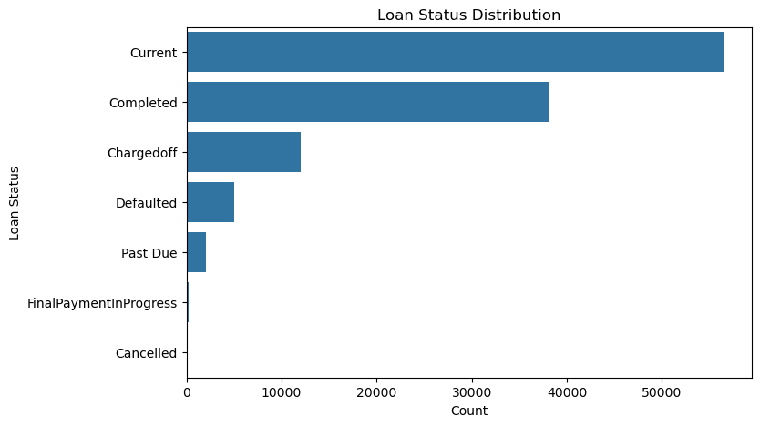

```python
#plotting the distribution for loan status
plt.figure(figsize= (8,5))
base_color = sb.color_palette()[0]
sb.countplot(data = loan_df, y = 'LoanStatus', color= base_color, order = loan_df['LoanStatus'].value_counts().index);
plt.xlabel('Count')
plt.ylabel('Loan Status')
plt.title('Loan Status Distribution');
```

Current loan status is in majority in comparison to other loans. Ther are quite a few loans that are charged off and defaulted, we can try to figure out if this can be minimized.

### Employment Status

```python
#Checking the categories for employemnt status
loan_df['EmploymentStatus'].value_counts()
```

```
Employed         67322
Full-time        26355
Self-employed     6134
Not available     5347
Other             3806
Part-time         1088
Not employed       835
Retired            795
Name: EmploymentStatus, dtype: int64
```

```python
#Creating a category for employment status
estatus_classes = ['Employed', 'Full-time', 'Self-employed', 'Not available', 'Other', 'Part-time', 'Not employed', 'Retired']
cat_create(estatus_classes, 'EmploymentStatus')
```

```python
loan_df['EmploymentStatus'].info()
```

```
<class 'pandas.core.series.Series'>
RangeIndex: 113937 entries, 0 to 113936
Series name: EmploymentStatus
Non-Null Count   Dtype
--------------   -----
111682 non-null  category
dtypes: category(1)
memory usage: 111.7 KB
```

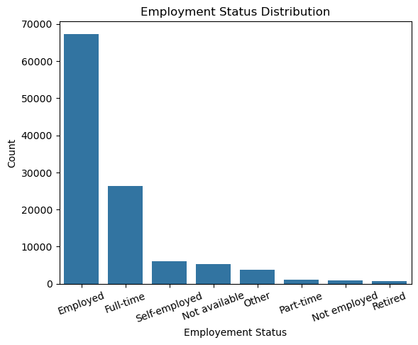

```python
#plotting the employement status distribution
sb.countplot(data = loan_df, x = 'EmploymentStatus', color = base_color, order = loan_df['EmploymentStatus'].value_counts().index)
plt.xticks(rotation = 20)
plt.xlabel('Employement Status')
plt.ylabel('Count')
plt.title('Employment Status Distribution');
```

There are about 65000 employees who are employed. And only a few people are unemployed and have some loan status in Prosper. However, there are more than 5000 people whose employment status is not available.

### Income Verifiable

```python
#creating dataframe for income verifiable
loan_df_sub = pd.DataFrame(loan_df['IncomeVerifiable'].value_counts().reset_index())
loan_df_sub
```

|  | index | IncomeVerifiable |
| --- | --- | --- |
| 0 | True | 105268 |
| 1 | False | 8669 |

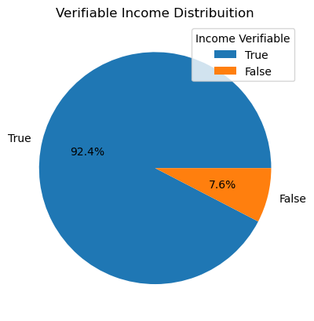

```python
#plotting the pie chart for income verifiable

labels = loan_df_sub['index']
plt.pie(data = loan_df_sub, x = 'IncomeVerifiable', labels= labels, autopct = '%.1f%%')
plt.legend(title = 'Income Verifiable')
plt.title('Verifiable Income Distribuition');
```

There are about 92.4% of people whose income is verified, so there are lower chances of having loan allocating issues with this background check.

### Borrower APR

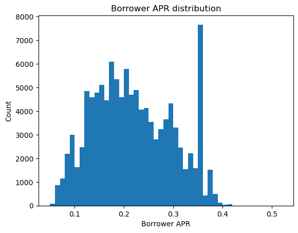

```python
#plotting borrower APR distribution
bins = np.arange(0.05, loan_df['BorrowerAPR'].max()+ 0.01, 0.01)
plt.hist(data = loan_df, x = 'BorrowerAPR', bins = bins)
plt.xlabel('Borrower APR')
plt.ylabel('Count')
plt.title('Borrower APR distribution');
```

### Income Range

```python
#Cleaning the income range column
loan_df.replace(to_replace = ['Not displayed', 'Not employed'], value = '$0', inplace = True)
```

```python
#finding the count of the varied category
loan_income = pd.DataFrame(loan_df['IncomeRange'].value_counts().reset_index())
loan_income
```

|  | index | IncomeRange |
| --- | --- | --- |
| 0 | $25,000-49,999 | 32192 |
| 1 | $50,000-74,999 | 31050 |
| 2 | $100,000+ | 17337 |
| 3 | $75,000-99,999 | 16916 |
| 4 | $1-24,999 | 7274 |
| 5 | $0 | 621 |

```python
#creating a category for income range
income_classes = ['$0', '$1-24,999', '$25,000-49,999', '$50,000-74,999', '$75,000-99,999', '$100,000+']
cat_create(income_classes, 'IncomeRange')
```

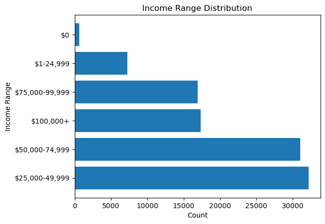

```python
#plotting the distribution
plt.barh(data = loan_income, y = 'index', width = 'IncomeRange')
plt.xlabel('Count')
plt.ylabel('Income Range')
plt.title('Income Range Distribution');
```

The majority of people lie in the category of dollars 25,000 - 49,999 and next in dollars 50,000 - 74,999. This can mean this is the lot with more loans applied.

### Occupation

```python
#Creating dataframe for occupation
loan_occ = pd.DataFrame(loan_df['Occupation'].value_counts()[:10].reset_index())
loan_occ
```

|  | index | Occupation |
| --- | --- | --- |
| 0 | Other | 28617 |
| 1 | Professional | 13628 |
| 2 | Computer Programmer | 4478 |
| 3 | Executive | 4311 |
| 4 | Teacher | 3759 |
| 5 | Administrative Assistant | 3688 |
| 6 | Analyst | 3602 |
| 7 | Sales - Commission | 3446 |
| 8 | Accountant/CPA | 3233 |
| 9 | Clerical | 3164 |

```python
#creating category for occupation
occ_classes = ['Other', 'Professional', 'Computer Programmer', 'Executive', 'Teacher', 'Administrative Assistant', 'Analyst', 'Sales-Commission', 'Accountant/CPA', 'Clerical']
cat_create(occ_classes, 'Occupation')
```

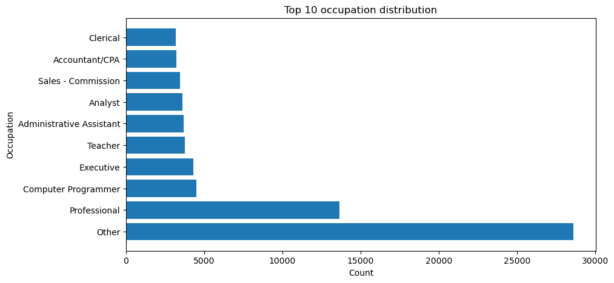

```python
#plotting occupation ditribution
plt.figure(figsize= (10,5))
plt.barh(loan_occ['index'], loan_occ['Occupation'])
plt.xlabel('Count')
plt.ylabel('Occupation')
plt.title('Top 10 occupation distribution');
```

A lot of people are in the other occupation category, this cannot give us more information

### Stated Monthly Income

```python
#Monthly income analysis
loan_df['StatedMonthlyIncome'].describe()
```

```
count    1.139370e+05
mean     5.608026e+03
std      7.478497e+03
min      0.000000e+00
25%      3.200333e+03
50%      4.666667e+03
75%      6.825000e+03
max      1.750003e+06
Name: StatedMonthlyIncome, dtype: float64
```

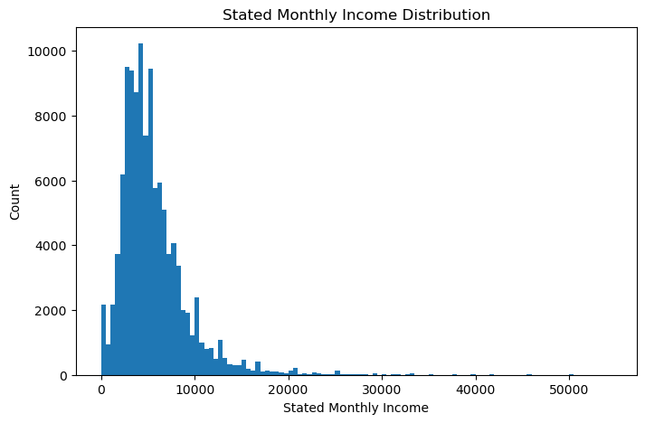

```python
#plotting the monthly income distribution
plt.figure(figsize= [8,5])
bins = np.arange(0, 55000, 500)
plt.hist(data = loan_df, x = 'StatedMonthlyIncome', bins = bins)
plt.xlabel('Stated Monthly Income')
plt.ylabel('Count')
plt.title('Stated Monthly Income Distribution');
```

The monthly income lies from 0 - 1,750,000, but there are many outliers as the main range lies between 0 - 15,000. The plot is right-skewed with being unimodal and has a mean of 5,600.

### Term

```python
#different categories in term
loan_df['Term'].unique()
```

```
array([36, 60, 12])
```

```python
#creating a category for term
term_class = [12, 36, 60]
cat_create(term_class, 'Term')
```

```python
#creating a dataframe for term
loan_term = pd.DataFrame(loan_df['Term'].value_counts().reset_index())
loan_term
```

|  | index | Term |
| --- | --- | --- |
| 0 | 36 | 87778 |
| 1 | 60 | 24545 |
| 2 | 12 | 1614 |

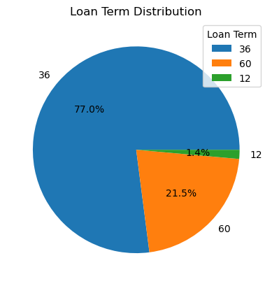

```python
#plotting the loan term distribution
labels = loan_term['index']
plt.pie(data = loan_term, x = 'Term', labels = labels, autopct= '%.1f%%' )
plt.legend(title = 'Loan Term')
plt.title('Loan Term Distribution');
```

There are 77% in the 36-month loan term. Only about 1.4% in 12 months and the rest in the 60-month loan term. So we can expect to have a lot of defaulters and charged off lying in a 36-month loan term.

### DebtToIncome Ratio

```python
#Analyzing the debt to income ratio data
loan_df['DebtToIncomeRatio'].describe()
```

```
count    105383.000000
mean          0.275947
std           0.551759
min           0.000000
25%           0.140000
50%           0.220000
75%           0.320000
max          10.010000
Name: DebtToIncomeRatio, dtype: float64
```

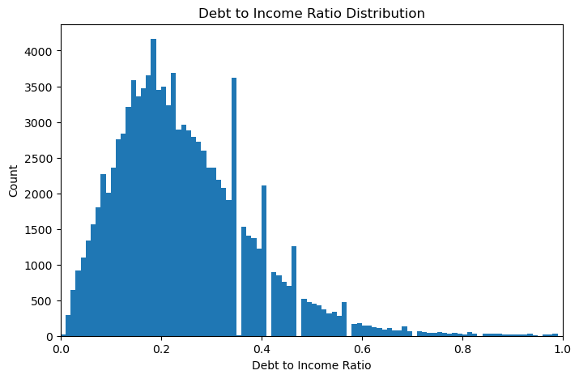

```python
#plotting the debt to income ratio
plt.figure(figsize= [8,5])
bins = np.arange(0, 1, 0.01)
plt.hist(data = loan_df, x = 'DebtToIncomeRatio', bins = bins)
plt.xlim(0,1)
plt.xlabel('Debt to Income Ratio')
plt.ylabel('Count')
plt.title('Debt to Income Ratio Distribution');
```

The entire plot looks right-skewed. However, there are a few gaps and peaks before the gaps. The drastic drop can be seen after 0.4, although the entire ratio lies between 0 and 1.

### Loan Original Amount

```python
#analyzing the loan original amount
loan_df['LoanOriginalAmount'].describe()
```

```
count    113937.00000
mean       8337.01385
std        6245.80058
min        1000.00000
25%        4000.00000
50%        6500.00000
75%       12000.00000
max       35000.00000
Name: LoanOriginalAmount, dtype: float64
```

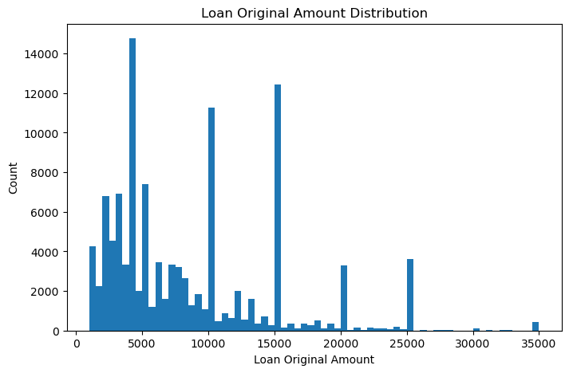

```python
#plotting the loan original amount distribution
plt.figure(figsize= [8,5])
bins = np.arange(1000, loan_df['LoanOriginalAmount'].max()+500, 500)
plt.hist(data = loan_df, x = 'LoanOriginalAmount', bins = bins)
# plt.xlim(0,1)
plt.xlabel('Loan Original Amount')
plt.ylabel('Count')
plt.title('Loan Original Amount Distribution');
```

There are large spikes at 5000, 10000, 15000, 20000, and 25000. After that the data has outliers. The majority of the data lies between 1000 to 25000.

### Discuss the distribution(s) of your variable(s) of interest. Were there any unusual points? Did you need to perform any transformations?

> The remaining analysis was done on the categorical and boolean data. Income Verifiable, Loan Term Distribution, Occupation, Income Range, Employment status, Loan Status. There was something unusual about the debt-to-income ratio with the drastic drops at three to four points.

> To convert various columns to categories a few transformations were done. Also, the handling of null values was done for the income range column.

### Of the features you investigated, were there any unusual distributions? Did you perform any operations on the data to tidy, adjust, or change the form of the data? If so, why did you do this?

> **Loan Status**: A majority of the people are currently having their loans with Prosper, the next in line are people who have completed their loan and charged off. There are only a few who have their loans past due or have canceled their loans. So, it can be said that the company is handling the loans pretty well.

> **Employment Status**: A large number of people who have loans are employed. With only a few people being part-time workers, not employed or retired. So this can ensure the possibility of people paying off the loan.

> **Income Verifiable**: About 92.4 % percent of people have their income verified, which shows the authenticity of the people taking the loan. A data frame was created for plotting the pie chart with the labels and percentages.

> **Borrower APR**: The distribution seems to be multimodal with many small peaks. However, there is one major peak at 0.35 APR. The data can be further analyzed to give a better understanding of the peaks.

> **Income Range**: 'Not displayed' and 'Not employed' all need to be updated with 0 as there is no income figure. The majority of people lie in the 25,000 - 49,999 range and with a small difference a lot of people lie in the 50,000 - 74,999 range.

> **Occupation**: A vast population of people taking loan lie in the 'other' category. So we cannot fully understand the occupation of people who are taking loans.

> **Term**: The columns were changed to categorical by creating a new category class for the term. The column was updated and then the pie chart was plotted. A lot of people have a loan term of 36 months, about 77% of the people and about 21.5% of the people had a loan with 60 months term and there were only 1.4% of people with 12 months of the loan term.

> **Debt to Income Ratio**: The distribution was plotted from 0 to 1. However, the majority of the data lies between 0 to 0.6 which is good as a lot of people have a debt-to-income ratio. However, there are some drastic drops in 3-4 different areas.

## Bivariate Exploration

> In this section, I have investigated relationships between pairs of variables in the data. Analysis has been done on the Quantitative vs Quantitative, Qualitative vs. Qualitative, and Quantitative vs. Qualitative data

```python
num_vars = ['BorrowerAPR', 'StatedMonthlyIncome', 'DebtToIncomeRatio', 'LoanOriginalAmount']
cat_vars = ['Term', 'LoanStatus', 'Occupation', 'EmploymentStatus', 'IncomeRange']
```

### Quantitative vs. Quantitative

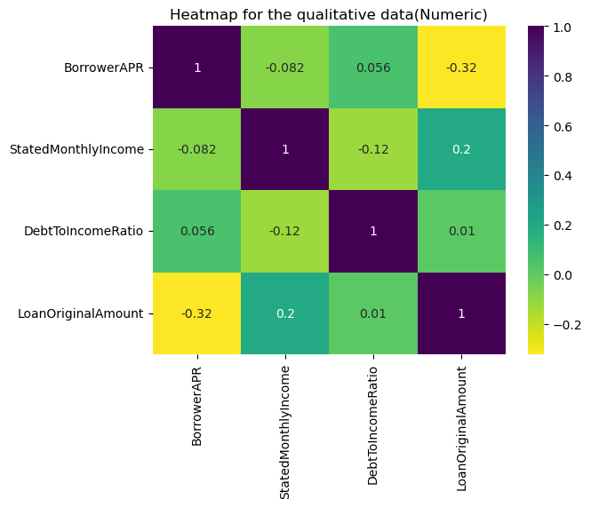

```python
#plotting the entire num_vars with num vars
sb.heatmap(loan_df[num_vars].corr(), annot= True, cmap= 'viridis_r')
plt.title('Heatmap for the qualitative data(Numeric)');
```

From the above plot clear analysis can be made that there is a positive correlation between debt to income and borrower APR, stated monthly income and loan amount, debt to income ratio, and loan original amount. The rest are negative. All the relations in the plot have a weak relation amongst them.

### Qualitative vs. Quantitative

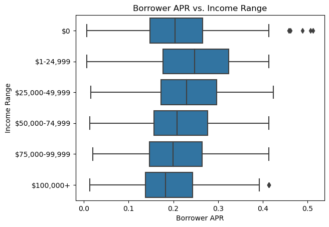

```python
#plotting borrower APR with income range
base_color = sb.color_palette()[0]
sb.boxplot(data = loan_df, x = 'BorrowerAPR', y = 'IncomeRange', color = base_color)
plt.xlabel('Borrower APR')
plt.ylabel('Income Range')
plt.title('Borrower APR vs. Income Range');
```

The people with income range of 25,000 - 49,999 have max APR of 0.42. However, the APR range for the income range of 1-24,999 is larger.

```python
#loading again to not have category datatype for loan status
loan_df2 = pd.read_csv('prosperLoanData.csv')
```

```python
loan_df2.loc[loan_df2['LoanStatus'].str.contains('Past Due'), 'LoanStatus'] = 'Past Due'
```

```python
#Taking only necessary values
loan_status = loan_df2.loc[loan_df2['LoanStatus'].isin(['Current', 'Completed', 'Chargedoff', 'Defaulted', 'Past Due'])]
```

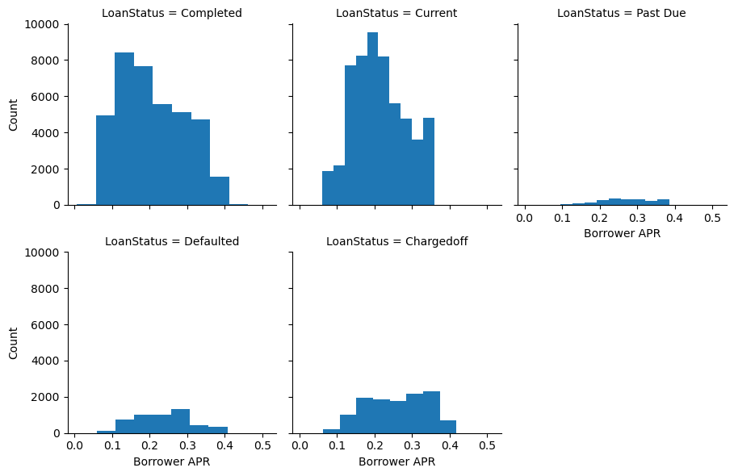

```python
#plotting loan status with borrower APR
g = sb.FacetGrid(data = loan_status, col = 'LoanStatus', col_wrap= 3)
g.map(plt.hist, 'BorrowerAPR')
g.set_xlabels('Borrower APR')
g.set_ylabels('Count');
```

The range of the Borrower APR is greater for the completed and charged off loan status, however the count of the completed is more.

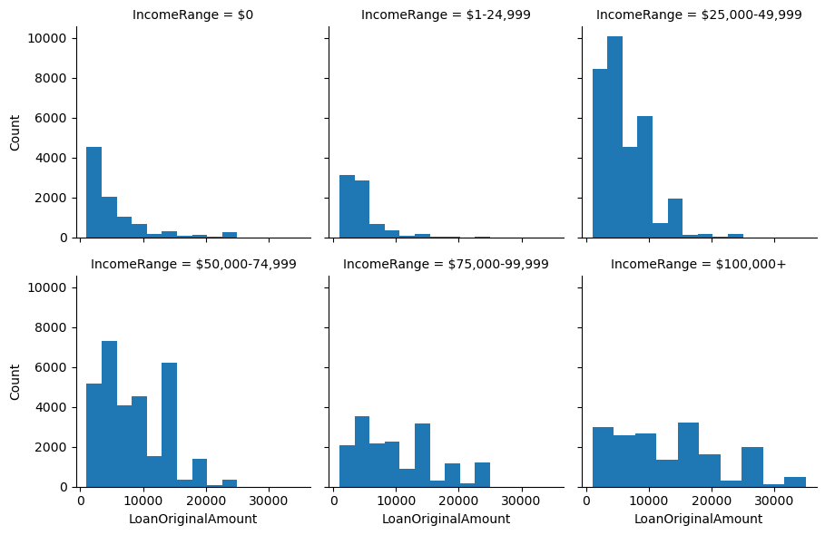

```python
g = sb.FacetGrid(data = loan_df, col = 'IncomeRange', col_wrap= 3)
g.map(plt.hist, 'LoanOriginalAmount')
g.set_ylabels('Count');
```

The income range of 25,000 - 49,999 have more people taking loan but majorly for loan amount of 2000 - 10,000.

### Qualitative vs. Qualitative

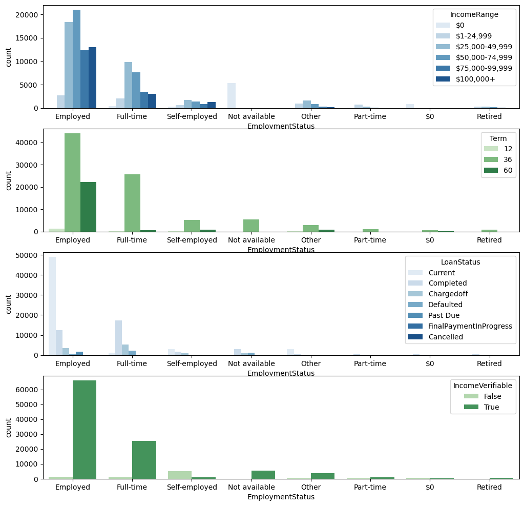

```python
#plotting various categorical data with Employment status
plt.figure(figsize=[12,12])

plt.subplot(4, 1, 1)
sb.countplot(data = loan_df, x = 'EmploymentStatus', hue = 'IncomeRange', palette = 'Blues')

plt.subplot(4, 1, 2)
sb.countplot(data = loan_df, x = 'EmploymentStatus', hue = 'Term', palette = 'Greens')

plt.subplot(4, 1, 3)
sb.countplot(data = loan_df, x = 'EmploymentStatus', hue = 'LoanStatus', palette = 'Blues')

plt.subplot(4, 1, 4)
sb.countplot(data = loan_df, x = 'EmploymentStatus', hue = 'IncomeVerifiable', palette = 'Greens');
```

### Talk about some of the relationships you observed in this part of the investigation. How did the feature(s) of interest vary with other features in the dataset?

> In the heat map, the relation between BorrowerAPR and Statted monthly income has a correlation of -0.082 which means there is negative and weak relation between them. The relation between Debt income ratio and borrower APR has positive and weak relations.

> The income range of 25,000 - 49,999 have more people taking a loan but majorly for a loan amount of 2000 - 10,000.

### Did you observe any interesting relationships between the other features (not the main feature(s) of interest)?

> The relation between the debt-to-income ratio and stated monthly income is negative and the stated monthly income to the original loan amount is positive, this is true as the people earning more can get more loans.

## Multivariate Exploration

> Based on the above observations I have decided to analyze the APR wrt the loan status and employement, loan original amount with the loan status and employment, and Loan original amount with the income range and loan status.

```python
employ_order = ['Full-time', 'Employed', 'Part-time', 'Self-employed', 'Other', 'Retired', 'Not available']
```

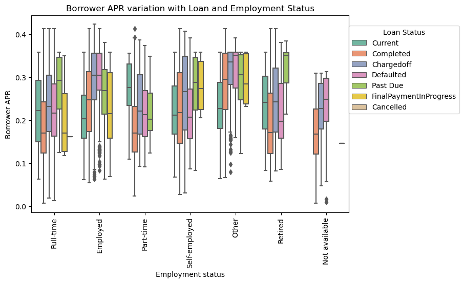

```python
#plotting
plt.figure(figsize= (8,5))
sb.boxplot(data=loan_df, y='BorrowerAPR',
           color=base_color, order=employ_order, x='EmploymentStatus', hue='LoanStatus', palette='Set2')
plt.legend(loc=(1, 0.5), title = 'Loan Status')
plt.xticks(rotation=90)
plt.xlabel('Employment status')
plt.ylabel('Borrower APR')
plt.title('Borrower APR variation with Loan and Employment Status');
```

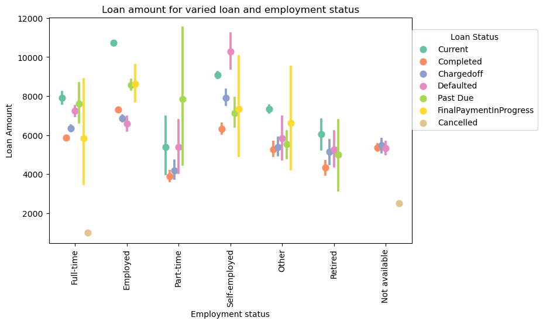

```python
#plotting
plt.figure(figsize= (8,5))
sb.pointplot(x='EmploymentStatus', y='LoanOriginalAmount', data=loan_df,
             hue='LoanStatus', join=False, dodge=0.5, order=employ_order, palette='Set2')
plt.legend(title = 'Loan Status', loc = (1, 0.5))
plt.xticks(rotation=90)
plt.xlabel('Employment status')
plt.ylabel('Loan Amount')
plt.title('Loan amount for varied loan and employment status');
```

> People working part-time have more loans past due dates indicating they take higher loans than they can afford to pay. Also, people who are self-employed have default loan status for larger loan amounts, which makes both a high-risk category for future loan approval.

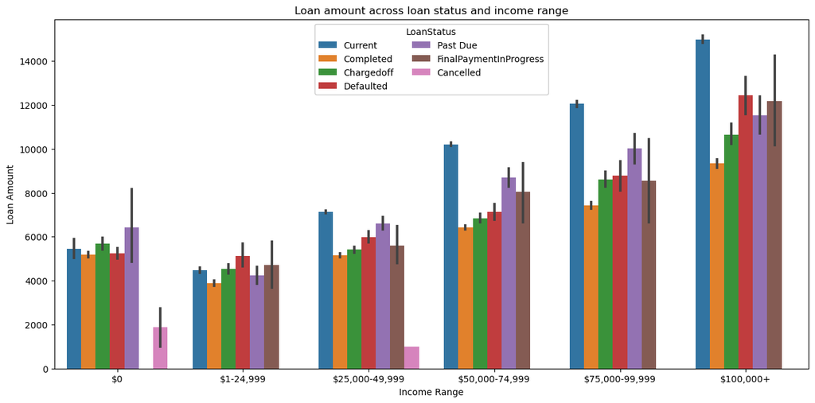

```python
#plotting
plt.figure(figsize = [15, 7])

ax = sb.barplot(data = loan_df, x = 'IncomeRange', y = 'LoanOriginalAmount', hue = 'LoanStatus')
ax.legend(loc = 9, ncol = 2, framealpha = 1, title = 'LoanStatus')
plt.xlabel('Income Range')
plt.ylabel('Loan Amount')
plt.title('Loan amount across loan status and income range');
```

> The loan amount does not increase linearly with the Income range but we can see that there is an increase in the loan amount with the increase in income.

### Talk about some of the relationships you observed in this part of the investigation. Were there features that strengthened each other in terms of looking at your feature(s) of interest?

> People working part-time have more loans past due dates indicating they take higher loans than they can afford to pay. Also, self-employed people have default loan status for larger loan amounts, which makes both a high-risk category for future loan approval.

> The loan amount does not increase linearly with the Income range but we can see that there is an increase in the loan amount with the increase in income.

### Were there any interesting or surprising interactions between features?

> Although there is a huge range for the final payment in the progress bar, there is very few completed loans range. This is surprising if people are doing the final payment, why is there small information on completed loans?

## Conclusions

> To summarize, it is clear that when the charged-off and default loan status categories are taken into consideration and proper vetting is done, it can help the company have more profit than loss. Also, if people cannot afford to take loans they must be continuously monitored before allocating the loans.